# Syracuse Tax Parcels

## Load Dataset

This dataset is located in GitHub:

```r
dat <- read.csv( "syr_parcels.csv", stringsAsFactors=F )
```

## About

This data set represents 42,000 tax parcels for the city of Syracuse, NY.

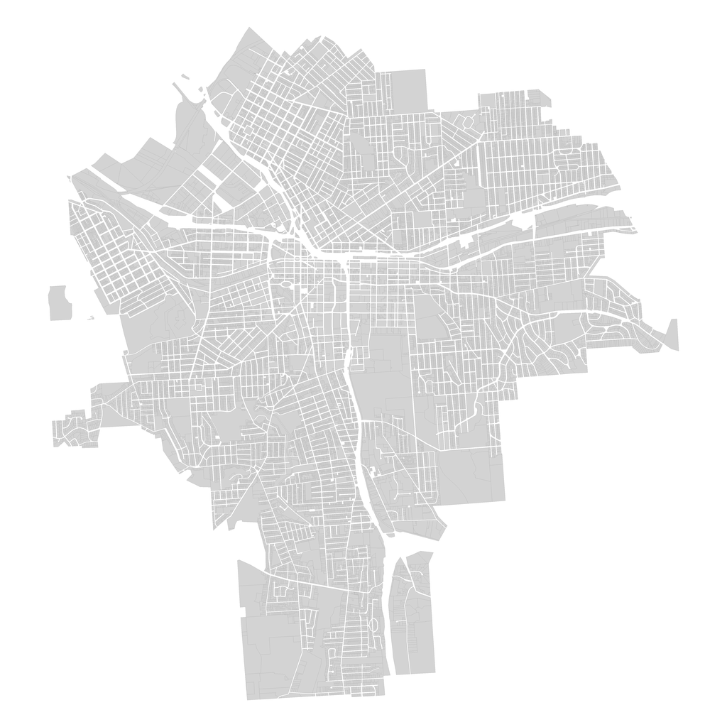

Syracuse Parcels

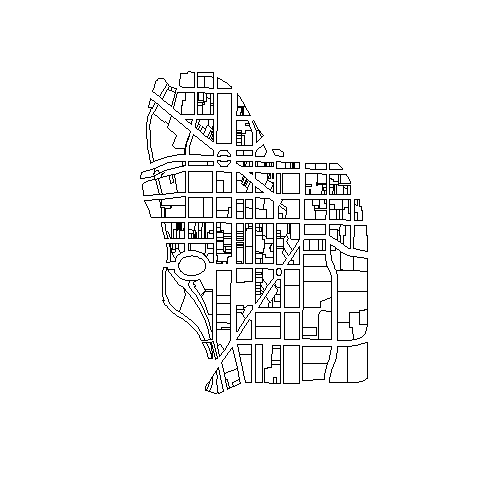

Downtown Syracuse

## Data Dictionary

This data set contains the following variables:

- **tax_id** - unique parcel ID (numeric)
- **neighborhood** - city neighborhood for tax parcel (character)
- **stnum** - parcel address (numeric)
- **stname** - parcel address (character)
- **zip** - parcel address (numeric)
- **owner** - property owner (character)
- **frontfeet** - length of the front of the lot (numeric)
- **depth** - depth of the lot (numeric)
- **sqft** - size of the parcel in square feet (numeric)
- **acres** - size of the parcel in acres (numeric)
- **yearbuilt** - year of construction for the building on the parcel (numeric)
- **age** - age of the building (numeric)
- **age_range** - age of the building by decade (factor)
- **land_use** - zoning purpose of the parcel (factor)
- **units** - number of units in multi-unit buildings (numeric)
- **residential** - is the parcel zoned for residential (T/F)
- **rental** - is the residential space zoned for rental (T/F)
- **vacantbuil** - is the building vacant (T/F)
- **assessedla** - assessed value of the parcel land (numeric)
- **assessedva** - assessed value of the parcel land plus buildings (numeric)
- **tax.exempt** - is the parcel tax exempt (T/F)
- **countytxbl** - value of parcel for tax purposes (numeric)
- **schooltxbl** - value of parcel for tax purposes (numeric)
- **citytaxabl** - value of parcel for tax purposes (numeric)
- **star** - does the parcel qualify for a residential tax break (T/F)
- **amtdelinqu** - amount of tax bill that is delinquint (numeric)
- **taxyrsdeli** - length of time tax bill is delinquint (numeric)
- **totint** - total interest owed for delinquint taxes (numeric)
- **overduewater** - total owed on overdue water bills (numeric)

## Data Preview

```r
head( dat )
```

|  | tax_id | neighborhood | stnum | stname | zip | owner | frontfeet | depth | sqft | acres | yearbuilt | age | age_range | land_use | units | residential | rental | vacantbuil | assessedla | assessedva | tax.exempt | countytxbl | schooltxbl | citytaxabl | star | amtdelinqu | taxyrsdeli | totint | overduewater |
| --- | --- | --- | --- | --- | --- | --- | --- | --- | --- | --- | --- | --- | --- | --- | --- | --- | --- | --- | --- | --- | --- | --- | --- | --- | --- | --- | --- | --- | --- |
| 1 | 1393130501 | South Valley | 2655 | VALLEY DR | 13215 | CLARMIN BUILDERS ONON COR | 67.20 | 50.00 | 2149.182 | 0.04933843 | NA | NA | NA | Vacant Land | 0 | FALSE | FALSE | FALSE | 475 | 500 | TRUE | 500 | 500 | 500 | NA | 0 | 0 | 0 | 0.00 |
| 2 | 1393130500 | South Valley | 2635 | VALLEY DR | 13120 | JOHNSTON LEE R | 104.80 | 46.50 | 6370.403 | 0.14624434 | 1925 | 90 | 81-90 | Single Family | 0 | TRUE | FALSE | FALSE | 10800 | 69300 | FALSE | 69300 | 69300 | 69300 | TRUE | 0 | 0 | 0 | 177.79 |
| 3 | 1437100600 | South Valley | 203 | HAYES TERR | 13224 | CHRISTO CRAIG S | 82.87 | 168.28 | 12910.006 | 0.29637297 | 1957 | 58 | 51-60 | Single Family | 0 | TRUE | FALSE | FALSE | 20200 | 88300 | FALSE | 88300 | 88300 | 88300 | TRUE | 0 | 0 | 0 | 0.00 |
| 4 | 1425100900 | South Valley | 100 | EDNA RD & CITY LINE | 13120 | HAWKINS FARMS INC | 65.00 | 160.89 | 10322.661 | 0.23697569 | 1958 | 57 | 51-60 | Single Family | 0 | TRUE | FALSE | FALSE | 18000 | 70500 | FALSE | 70500 | 70500 | 70500 | NA | 0 | 0 | 0 | 0.00 |
| 5 | 1425101000 | South Valley | 104 | EDNA RD | 13205 | PETERS LYNNETTE | 65.00 | 160.89 | 10457.843 | 0.24007904 | 1965 | 50 | 41-50 | Single Family | 0 | TRUE | FALSE | FALSE | 18000 | 74000 | FALSE | 74000 | 74000 | 74000 | TRUE | 0 | 0 | 0 | 0.00 |
| 6 | 1425101100 | South Valley | 108 | EDNA RD | 13205 | MITCHELL LOTAN G | 65.00 | 160.89 | 10457.855 | 0.24007931 | 1954 | 61 | 61-70 | Single Family | 0 | TRUE | FALSE | FALSE | 18000 | 95000 | FALSE | 95000 | 95000 | 95000 | TRUE | 0 | 0 | 0 | 0.00 |

## Neighborhoods

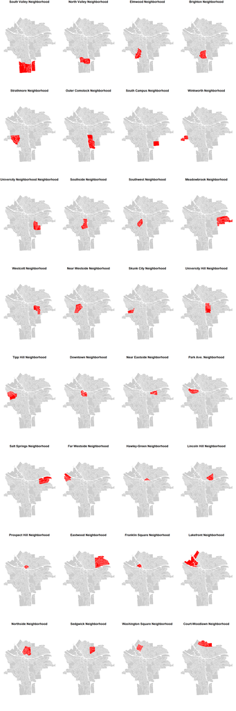

## Land Use

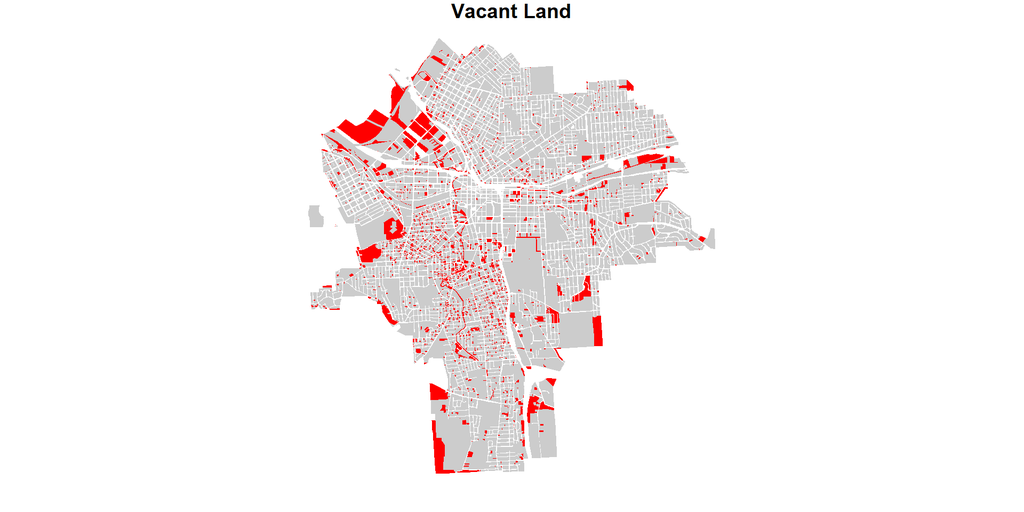

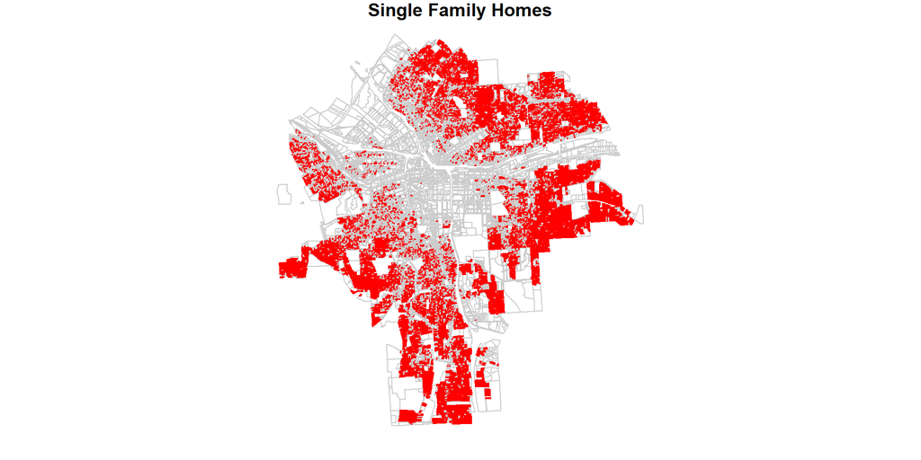

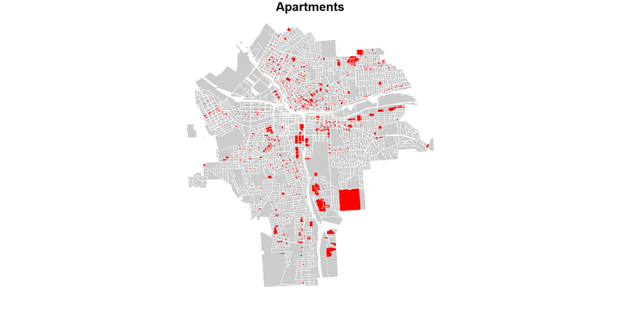

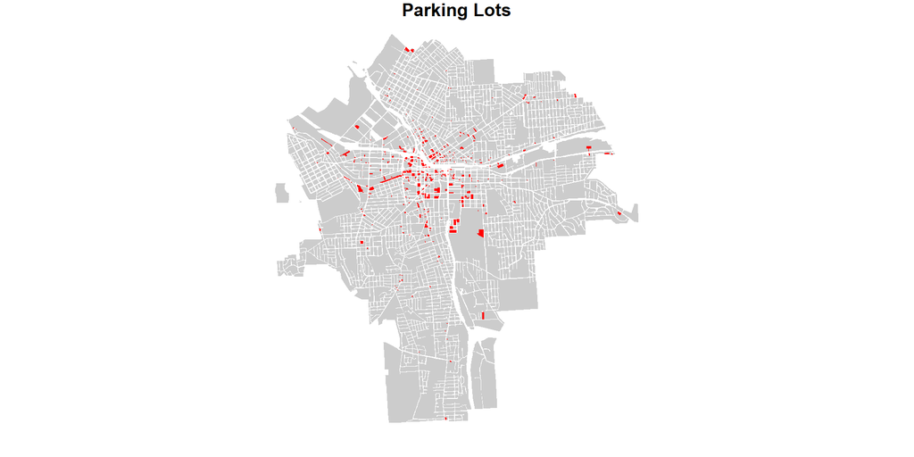

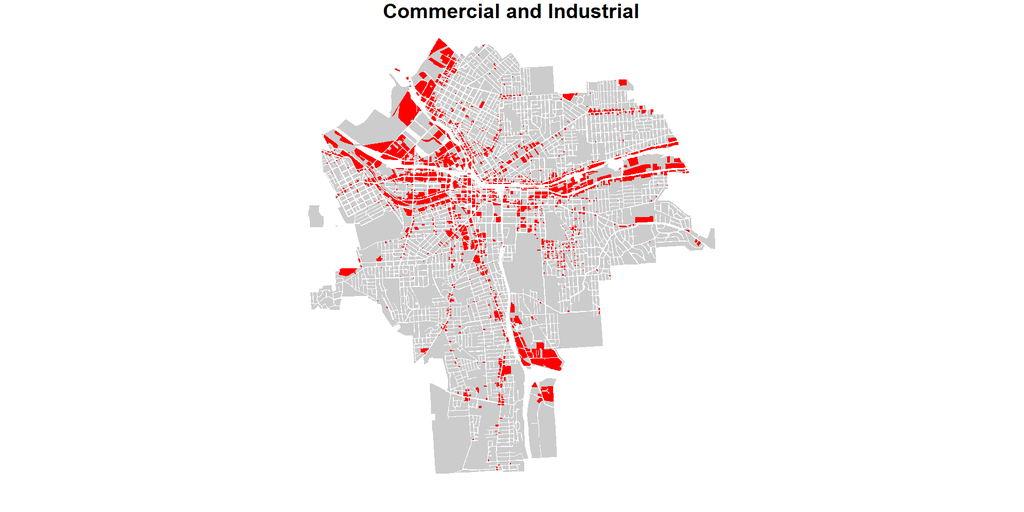

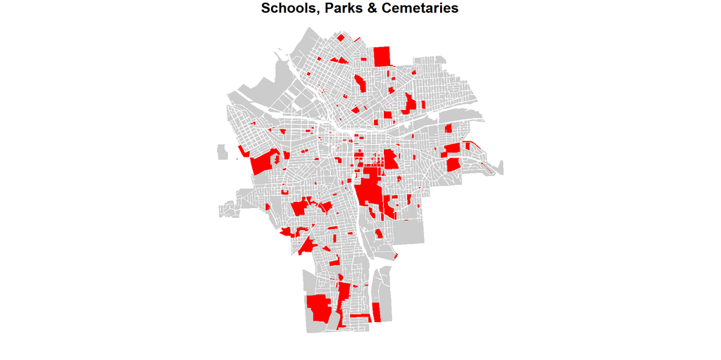

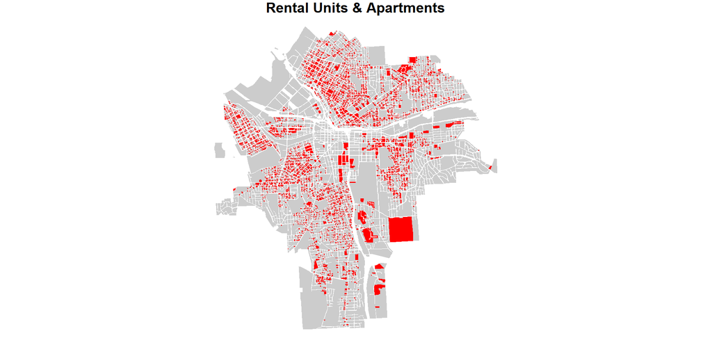

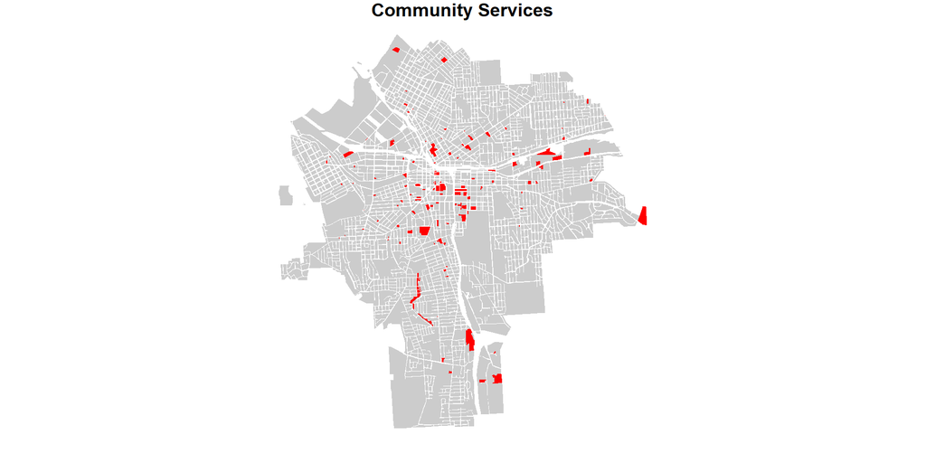

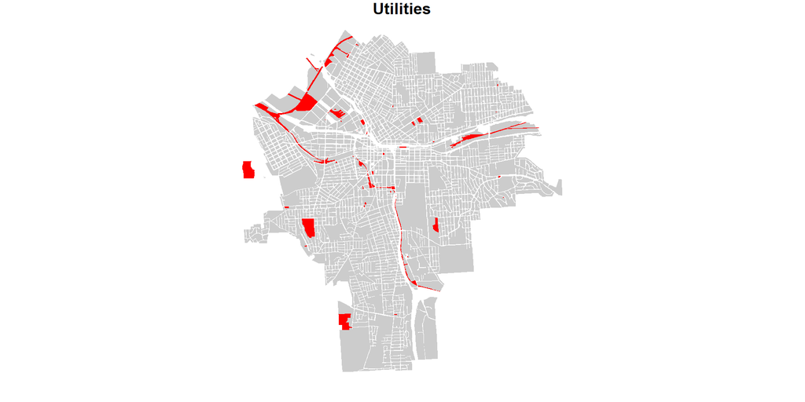

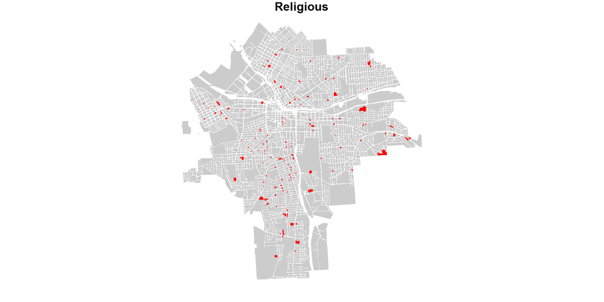

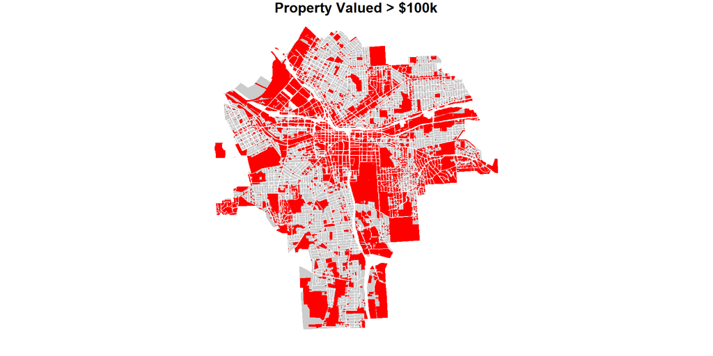

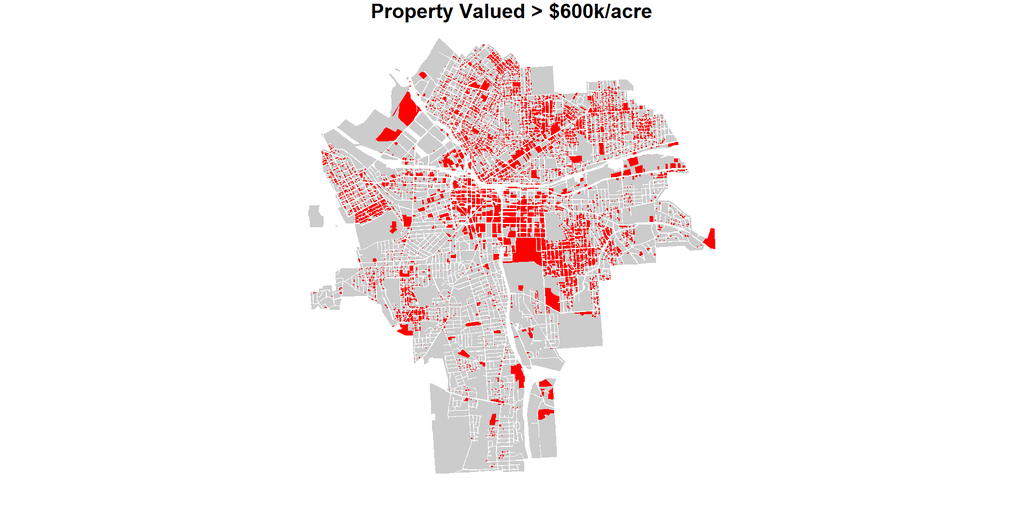

[2 more figures not shown]